# chiptsne2_usage

Joe Boyd

2023-06-14

# 1 Introduction

*chiptsne2* (working name only) is a new R package that accomplishes 2 things:

1. It supports the use of tSNE (and UMAP and PCA) in the analysis of enrichment profiles at regions of interest across the genome in ChIPseq experiments. Though developed for ChIPseq, the same procedures can be applied to ATACseq, BSseq, almost any kind of NGS really.
2. It provides a user friendly and robust way to use *seqsetvis*.

*seqsetvis* provides a way to work interactively via Rstudio with sequencing data in a tidy formatted way, leveraging the power of parallel processing and the [data.table](https://cran.r-project.org/web/packages/data.table/vignettes/datatable-intro.html) package and opening up the world of [ggplot2](https://ggplot2.tidyverse.org/) for visualization of NGS data.

*seqsetvis* does have issues with using more RAM than necessary and it requires some proficiency with *data.table* to use effectively. *chiptsne2* addresses both of these problems, and makes numerous other improvements to improve its usability.

*chiptsne2* key features:

1. *ChIPtsne2* class implemented as an extension of the bioc *SummarizedExperiment* class. This provides greater usability right of the bat.
2. Since you have to create a *ChIPtsne2* object, we can catch errors early and provide useful feedback to resolve them.
3. All package methods are build for use with the [magrittr](https://cran.r-project.org/web/packages/magrittr/vignettes/magrittr.html) pipe, %>%. This enables concise and readable workflows.
4. *ChIPtsne2* objects maintain a history of all package methods applied to them. Importantly, the history from one object can be applied to any number of other objects. This allows for workflows to be developed and reproducibly deployed.

# 2 Getting Started

First, load *chiptsne2* and supporting packages.

```r
suppressPackageStartupMessages({
    library(chiptsne2)
    library(tidyverse)
    library(GenomicRanges)
    library(SummarizedExperiment)
})
options(mc.cores = 20)
```

## 2.1 Quick Start

Before getting into the details, here’s what a *chiptsne2* workflow looks like:

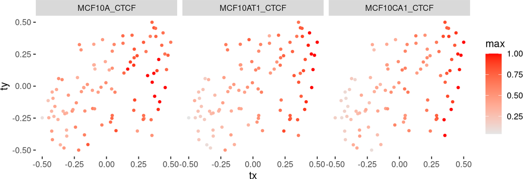

```r
ct2_quick = ChIPtsne2.from_tidy(
    exampleProfDT(),
    exampleQueryGR()
)

ct2_quick = ct2_quick %>%
    setSeed(0) %>%
    calculateSignalCapValue() %>%
    normalizeSignalCapValue() %>%
    centerProfilesAndTrim(view_size = 200) %>%
    dimReduceTSNE() %>%
    groupRegionsBySignalCluster(group_VAR = "cluster") %>%
    groupRegionsByDimReduceCluster(group_VAR = "tsne_group")

theme_update(panel.background = element_blank())
plotDimReducePoints(ct2_quick)+
    coord_fixed() +
    scale_color_gradient(low = "gray90", high = "red")
```

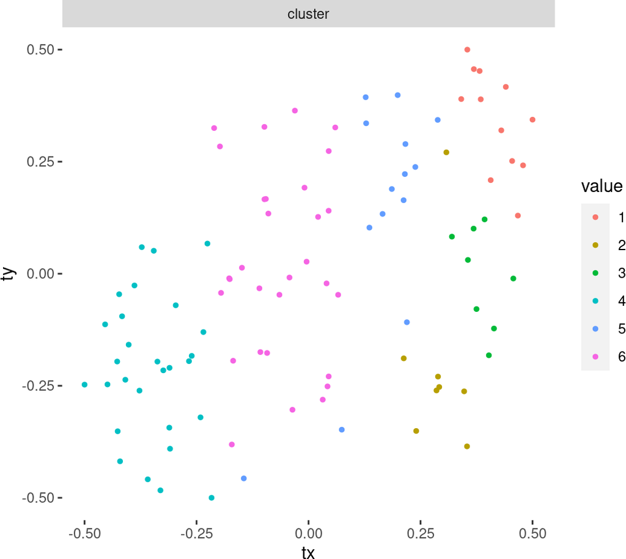

```r
plotDimReducePoints(ct2_quick, color_VAR = "cluster") +
    coord_fixed()
```

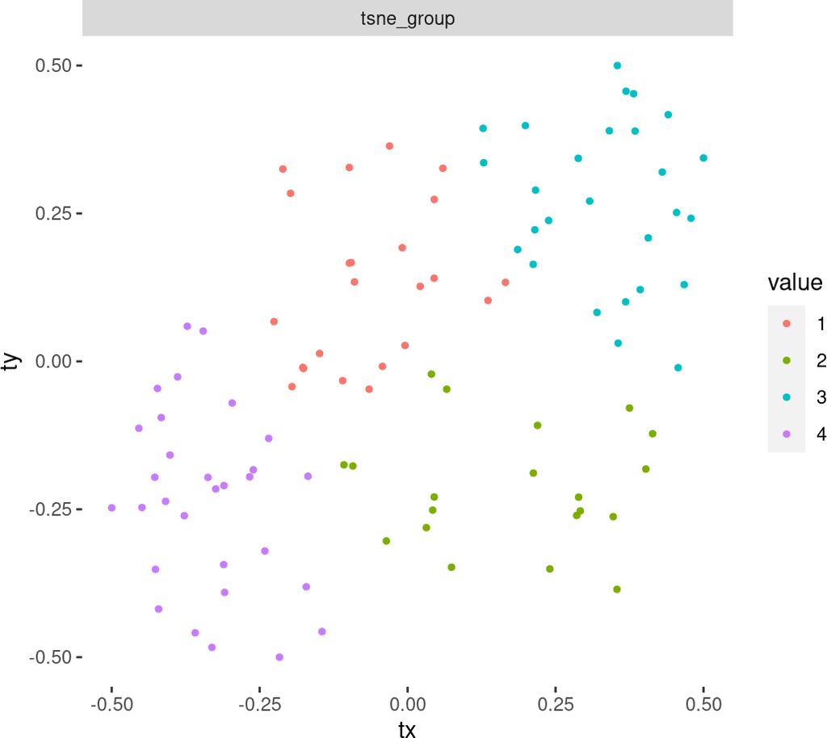

```r
plotDimReducePoints(ct2_quick, color_VAR = "tsne_group")+
    coord_fixed()
```

## 2.2 Rerunning

The history of any ChIPtsne2 object can be used to rerun complete workflows for convenience and reprodcibility.

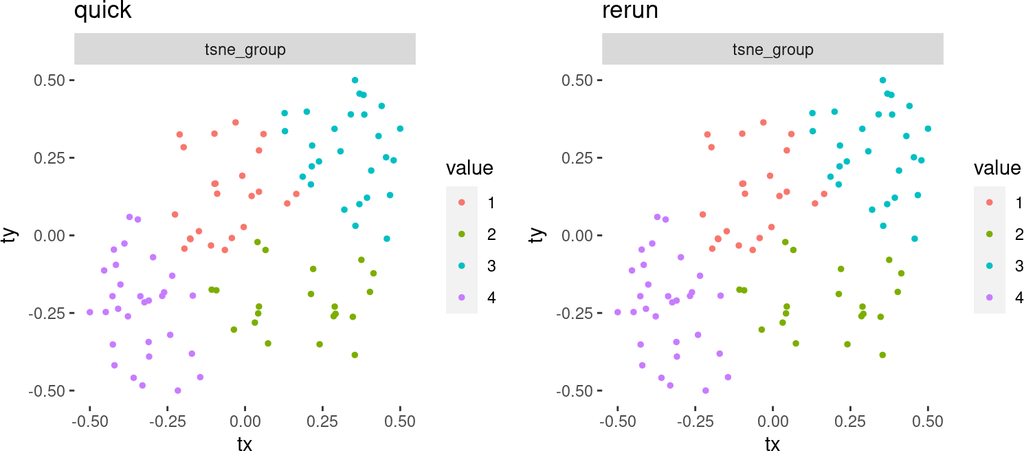

```r
ct2_rerun = ChIPtsne2.from_tidy(
    exampleProfDT(),
    exampleQueryGR()
)
ct2_rerun = rerun_history(ct2_rerun, history_source = ct2_quick)
cowplot::plot_grid(
    plotDimReducePoints(ct2_quick, color_VAR = "tsne_group")+
        coord_fixed() +
        labs(title = "quick"),
    plotDimReducePoints(ct2_rerun, color_VAR = "tsne_group")+
        coord_fixed() +
        labs(title = "rerun")
)
```

Running the same history with identical inputs yields identical results. We could of course modify the signal data or query GRanges, or even modify the history, most commonly by changing the random seed. A history that does not include setSeed will not be reproducible.

# 3 Details

To use *chiptsne2*, we need to create a ChIPtsne2 object. There are two intended ways to go about this, either ChIPtsne2.from_FetchConfig or ChIPtsne2.from_tidy. ChIPtsne2.from_FetchConfig relies on a FetchConfig object to allow *chiptsne2* to fetch signal as needed. ChIPtsne2.from_tidy relies on you to having already fetched signal using *seqsetvis* ssvFetch*. The latter provides more flexibility but places more responsibility on the user. Without providing a FetchConfig, some *chiptsne2* methods will not work.

Either way, we also need a set of query GRanges. These should represent areas of interest, such as peak calls or TSSes (transcription start sites).

Let’s start with making a meaningful set or regions to query.

## 3.1 Query GRanges

The following procedure selects narrowPeak files for 3 histone modifications in 2 cell lines, loads all peaks, overlaps them, resizes 1.5kb and downsamples to 500 regions for speed.

This is a good general approach to creating a meaningful tSNE projection. If you plan on visualizing something more selective, such as differential chromatin regions, it’s a good idea to add some amount (30-50% of all regions) of “background” regions to allow the tSNE space to remain contiguous.

```r
sel_marks = c("H3K4me3", "H3K27ac", "H3K4me1", "input")
sel_cells = c("MCF10A", "MCF10AT1")

np_file_dt = data.BRCAprogression::chip.setup_narrowPeak_files()
np_file_dt = np_file_dt %>%
    filter(cell %in% sel_cells & mark %in% sel_marks)
np_grs = seqsetvis::easyLoad_narrowPeak(np_file_dt$file, file_names = np_file_dt$group)
olap_gr = seqsetvis::ssvOverlapIntervalSets(np_grs)
# for speed in this example, we'll only use 500 regions
query_gr = olap_gr %>%
    resize(width = 1.5e3, fix = "center") %>%
    sample(size = 500)
```

## 3.2 ChIPtsne2

### 3.2.1 from_FetchConfig

We need some files to pull signal from. We can use either bam files or bigwig files.

To create a FetchConfig object, at a minimum we need a vector of file paths. If we include those file paths and meta data into a data.frame, that meta data will be carried through to the final ChIPtsne2 object.

```r
bam_file_dt = data.BRCAprogression::chip.setup_bam_files(pooled = TRUE)
bam_file_dt = bam_file_dt %>%
    filter(cell %in% c("MCF10A", "MCF10AT1") & mark %in% c("H3K4me3", "H3K27ac", "H3K4me1", "input"))
bam_file_dt$fragLens = 200
DT::datatable(bam_file_dt)
```

|  | file | cell | mark | rep | name | label | label_split | group | group_split | mapped_reads | fragLens |
| --- | --- | --- | --- | --- | --- | --- | --- | --- | --- | --- | --- |
| 1 | /slipstream_old/home/joeboyd/R_workspace/data.BRCAprogression.big_data/chipseq/MCF10A_H3K4me3_pooled.Aligned.sortedByCoord.out.bam | MCF10A | H3K4me3 | pooled | MCF10A_H3K4me3_pooled | MCF10A H3K4me3 pooled | MCF10A H3K4me3 pooled | MCF10A H3K4me3 | MCF10A H3K4me3 | 159567091 | 200 |
| 2 | /slipstream_old/home/joeboyd/R_workspace/data.BRCAprogression.big_data/chipseq/MCF10AT1_H3K4me3_pooled.Aligned.sortedByCoord.out.bam | MCF10AT1 | H3K4me3 | pooled | MCF10AT1_H3K4me3_pooled | MCF10AT1 H3K4me3 pooled | MCF10AT1 H3K4me3 pooled | MCF10AT1 H3K4me3 | MCF10AT1 H3K4me3 | 55694862 | 200 |
| 3 | /slipstream_old/home/joeboyd/R_workspace/data.BRCAprogression.big_data/chipseq/MCF10A_H3K4me1_pooled.Aligned.sortedByCoord.out.bam | MCF10A | H3K4me1 | pooled | MCF10A_H3K4me1_pooled | MCF10A H3K4me1 pooled | MCF10A H3K4me1 pooled | MCF10A H3K4me1 | MCF10A H3K4me1 | 176377521 | 200 |
| 4 | /slipstream_old/home/joeboyd/R_workspace/data.BRCAprogression.big_data/chipseq/MCF10AT1_H3K4me1_pooled.Aligned.sortedByCoord.out.bam | MCF10AT1 | H3K4me1 | pooled | MCF10AT1_H3K4me1_pooled | MCF10AT1 H3K4me1 pooled | MCF10AT1 H3K4me1 pooled | MCF10AT1 H3K4me1 | MCF10AT1 H3K4me1 | 105757995 | 200 |
| 5 | /slipstream_old/home/joeboyd/R_workspace/data.BRCAprogression.big_data/chipseq/MCF10A_H3K27ac_pooled.Aligned.sortedByCoord.out.bam | MCF10A | H3K27ac | pooled | MCF10A_H3K27ac_pooled | MCF10A H3K27ac pooled | MCF10A H3K27ac pooled | MCF10A H3K27ac | MCF10A H3K27ac | 174870378 | 200 |
| 6 | /slipstream_old/home/joeboyd/R_workspace/data.BRCAprogression.big_data/chipseq/MCF10AT1_H3K27ac_pooled.Aligned.sortedByCoord.out.bam | MCF10AT1 | H3K27ac | pooled | MCF10AT1_H3K27ac_pooled | MCF10AT1 H3K27ac pooled | MCF10AT1 H3K27ac pooled | MCF10AT1 H3K27ac | MCF10AT1 H3K27ac | 102992771 | 200 |
| 7 | /slipstream_old/home/joeboyd/R_workspace/data.BRCAprogression.big_data/chipseq/MCF10A_input_pooled.Aligned.sortedByCoord.out.bam | MCF10A | input | pooled | MCF10A_input_pooled | MCF10A input pooled | MCF10A input pooled | MCF10A input | MCF10A input | 57167358 | 200 |
| 8 | /slipstream_old/home/joeboyd/R_workspace/data.BRCAprogression.big_data/chipseq/MCF10AT1_input_pooled.Aligned.sortedByCoord.out.bam | MCF10AT1 | input | pooled | MCF10AT1_input_pooled | MCF10AT1 input pooled | MCF10AT1 input pooled | MCF10AT1 input | MCF10AT1 input | 38113570 | 200 |

We have a nice data.frame with sample metadata, but we could also just use file paths to create a FetchConfig. This is the simplest way to create a FetchConfig.

```r
bam_files = bam_file_dt[1:2,]$file
simple_fetch_config = FetchConfig.from_files(bam_files)

ct2_simple = ChIPtsne2.from_FetchConfig(
    simple_fetch_config,
    query_gr)
DT::datatable(as.data.frame(colData(ct2_simple)))
```

|  | file |
| --- | --- |
| MCF10A_H3K4me3_pooled.Aligned.sortedByCoord.out.bam | /slipstream_old/home/joeboyd/R_workspace/data.BRCAprogression.big_data/chipseq/MCF10A_H3K4me3_pooled.Aligned.sortedByCoord.out.bam |
| MCF10AT1_H3K4me3_pooled.Aligned.sortedByCoord.out.bam | /slipstream_old/home/joeboyd/R_workspace/data.BRCAprogression.big_data/chipseq/MCF10AT1_H3K4me3_pooled.Aligned.sortedByCoord.out.bam |

FetchConfig using data.frame of file paths and meta data:

```r
full_fetch_config = FetchConfig(bam_file_dt, name_VAR = "group")

ct2_full = ChIPtsne2.from_FetchConfig(
    full_fetch_config,
    query_gr)
DT::datatable(as.data.frame(colData(ct2_full)))
```

|  | file | cell | mark | rep | name | label | label_split | group_split | mapped_reads | fragLens |
| --- | --- | --- | --- | --- | --- | --- | --- | --- | --- | --- |
| MCF10A H3K4me3 | /slipstream_old/home/joeboyd/R_workspace/data.BRCAprogression.big_data/chipseq/MCF10A_H3K4me3_pooled.Aligned.sortedByCoord.out.bam | MCF10A | H3K4me3 | pooled | MCF10A_H3K4me3_pooled | MCF10A H3K4me3 pooled | MCF10A H3K4me3 pooled | MCF10A H3K4me3 | 159567091 | 200 |
| MCF10AT1 H3K4me3 | /slipstream_old/home/joeboyd/R_workspace/data.BRCAprogression.big_data/chipseq/MCF10AT1_H3K4me3_pooled.Aligned.sortedByCoord.out.bam | MCF10AT1 | H3K4me3 | pooled | MCF10AT1_H3K4me3_pooled | MCF10AT1 H3K4me3 pooled | MCF10AT1 H3K4me3 pooled | MCF10AT1 H3K4me3 | 55694862 | 200 |
| MCF10A H3K4me1 | /slipstream_old/home/joeboyd/R_workspace/data.BRCAprogression.big_data/chipseq/MCF10A_H3K4me1_pooled.Aligned.sortedByCoord.out.bam | MCF10A | H3K4me1 | pooled | MCF10A_H3K4me1_pooled | MCF10A H3K4me1 pooled | MCF10A H3K4me1 pooled | MCF10A H3K4me1 | 176377521 | 200 |
| MCF10AT1 H3K4me1 | /slipstream_old/home/joeboyd/R_workspace/data.BRCAprogression.big_data/chipseq/MCF10AT1_H3K4me1_pooled.Aligned.sortedByCoord.out.bam | MCF10AT1 | H3K4me1 | pooled | MCF10AT1_H3K4me1_pooled | MCF10AT1 H3K4me1 pooled | MCF10AT1 H3K4me1 pooled | MCF10AT1 H3K4me1 | 105757995 | 200 |
| MCF10A H3K27ac | /slipstream_old/home/joeboyd/R_workspace/data.BRCAprogression.big_data/chipseq/MCF10A_H3K27ac_pooled.Aligned.sortedByCoord.out.bam | MCF10A | H3K27ac | pooled | MCF10A_H3K27ac_pooled | MCF10A H3K27ac pooled | MCF10A H3K27ac pooled | MCF10A H3K27ac | 174870378 | 200 |
| MCF10AT1 H3K27ac | /slipstream_old/home/joeboyd/R_workspace/data.BRCAprogression.big_data/chipseq/MCF10AT1_H3K27ac_pooled.Aligned.sortedByCoord.out.bam | MCF10AT1 | H3K27ac | pooled | MCF10AT1_H3K27ac_pooled | MCF10AT1 H3K27ac pooled | MCF10AT1 H3K27ac pooled | MCF10AT1 H3K27ac | 102992771 | 200 |
| MCF10A input | /slipstream_old/home/joeboyd/R_workspace/data.BRCAprogression.big_data/chipseq/MCF10A_input_pooled.Aligned.sortedByCoord.out.bam | MCF10A | input | pooled | MCF10A_input_pooled | MCF10A input pooled | MCF10A input pooled | MCF10A input | 57167358 | 200 |
| MCF10AT1 input | /slipstream_old/home/joeboyd/R_workspace/data.BRCAprogression.big_data/chipseq/MCF10AT1_input_pooled.Aligned.sortedByCoord.out.bam | MCF10AT1 | input | pooled | MCF10AT1_input_pooled | MCF10AT1 input pooled | MCF10AT1 input pooled | MCF10AT1 input | 38113570 | 200 |

### 3.2.2 from_tidy

```r
prof_gr = seqsetvis::ssvFetchBam(bam_file_dt[1:2], query_gr, fragLens = 200)
ct2_tidy = ChIPtsne2.from_tidy(prof_gr, query_gr, name_VAR = "group")
# you could also do any normalization or other transformations before
prof_df = prof_gr %>%
    as.data.frame %>%
    mutate(RPM = y / mapped_reads * 1e6)
# undebug(ChIPtsne2.from_tidy)
ct2_tidy2 = ChIPtsne2.from_tidy(prof_df, query_gr, value_VAR = "RPM", name_VAR = "group")
```

## 3.3 Normalization

### 3.3.1 RPM

Reads-per-million (RPM) normalizes for the depth of sequencing. “mapped_reads” must be present in the sample metadata for this to work.

```r
getSampleMetaData(ct2_full) %>%
    select(group, mapped_reads)
```

```
##                             group mapped_reads
## MCF10A H3K4me3     MCF10A H3K4me3    159567091
## MCF10AT1 H3K4me3 MCF10AT1 H3K4me3     55694862
## MCF10A H3K4me1     MCF10A H3K4me1    176377521
## MCF10AT1 H3K4me1 MCF10AT1 H3K4me1    105757995
## MCF10A H3K27ac     MCF10A H3K27ac    174870378
## MCF10AT1 H3K27ac MCF10AT1 H3K27ac    102992771
## MCF10A input         MCF10A input     57167358
## MCF10AT1 input     MCF10AT1 input     38113570
```

```r
ct2_rpm = ct2_full %>%
    normalizeSignalRPM()


cbind(
    raw = assay(ct2_full, "max") %>% colSums,
    RPM = assay(ct2_rpm, "max") %>% colSums
)
```

```
##                    raw       RPM
## MCF10A H3K4me3   39546 247.83306
## MCF10AT1 H3K4me3 22160 397.88230
## MCF10A H3K4me1   49900 282.91587
## MCF10AT1 H3K4me1 14020 132.56681
## MCF10A H3K27ac   33438 191.21592
## MCF10AT1 H3K27ac 17979 174.56565
## MCF10A input      4596  80.39553
## MCF10AT1 input    2615  68.61073
```

### 3.3.2 Cap

*chiptsne2* provides a normalization method where values are re-scaled to be from 0-1 based on a provided “signal cap” per sample. By default, this cap is calculated as the 95th quantile of max signal per region.

```r
ct2_cap = ct2_full %>%
    calculateSignalCapValue(cap_quantile = .95) %>%
    normalizeSignalCapValue()

cbind(
    raw = assay(ct2_full, "max") %>% colSums,
    cap = assay(ct2_cap, "max") %>% colSums
)
```

```
##                    raw       cap
## MCF10A H3K4me3   39546 149.66703
## MCF10AT1 H3K4me3 22160 229.64714
## MCF10A H3K4me1   49900  71.89114
## MCF10AT1 H3K4me1 14020 313.53846
## MCF10A H3K27ac   33438 147.24892
## MCF10AT1 H3K27ac 17979 235.07018
## MCF10A input      4596  68.11481
## MCF10AT1 input    2615 306.75000
```

```r
ct2_cap50 = ct2_full %>%
    calculateSignalCapValue() %>%
    normalizeSignalCapValue(minimum_ceiling = 50)

# note the low signal input samples are much lower with a minimum ceiling.
cbind(
    raw = assay(ct2_full, "max") %>% colSums,
    cap50 = assay(ct2_cap50, "max") %>% colSums
)
```

```
##                    raw     cap50
## MCF10A H3K4me3   39546 149.66703
## MCF10AT1 H3K4me3 22160 229.64714
## MCF10A H3K4me1   49900  71.89114
## MCF10AT1 H3K4me1 14020  84.74000
## MCF10A H3K27ac   33438 147.24892
## MCF10AT1 H3K27ac 17979 235.07018
## MCF10A input      4596  68.11481
## MCF10AT1 input    2615  52.26000
```

```r
# this reproduces the effect of minimum_ceiling = 50, but you could do whatever
prof_dt = getTidyProfile(ct2_full)
cap_dt = seqsetvis::calc_norm_factors(prof_dt, by2 = "group")
cap_dt = mutate(cap_dt, y_cap_value = ifelse(y_cap_value < 50, 50, y_cap_value))
ct2_cap_manual = ct2_full %>%
    normalizeSignalCapValue(signal_cap_data = cap_dt, signal_cap_VAR = "y_cap_value")

cbind(
    raw = assay(ct2_full, "max") %>% colSums,
    manual = assay(ct2_cap_manual, "max") %>% colSums
)
```

[output not shown]